ChimeraMapR · v0.7.0

# Running `chimera_cli.R` from the terminal

A hands-on walkthrough of ChimeraMapR's batch command-line interface — the same haplotype-switch analysis as the Shiny app, driven from a shell prompt against real yeast chromosome data.

R ≥ 4.1 Rscript chimera_cli.R S. cerevisiae chrI test data

## What you need first

- R ≥ 4.1, with `shiny`, `data.table`, `ggplot2`, `pracma`, `Matrix`, `Rcpp`, `igraph`, and `optparse` installed (`optparse` is only needed for the CLI).
- A C++ toolchain (Xcode CLT on macOS) — `chimera_functions.R` compiles a Rcpp HMM the first time it's sourced.
- Three input files: a read-level SNP call CSV, a SNP definition file (CSV or VCF), and a `.fai` chromosome size index. See *Input files* in the README for the exact schema — this tutorial uses ready-made copies from `test_data/`.

**No install step needed to try this.** If you've cloned the ChimeraMapR repo, `test_data/chrI.csv.gz`, `test_data/chrI_SNPs.vcf.gz`, and `test_data/ref_genome.fasta.fai` are already there — every command below runs as-is from the repo root.

01

## Check the option list

The CLI takes three positional arguments — read data, SNP data, chromosome sizes — plus flags for filtering, tuning, and output mode. Run it with no arguments (or `--help`) to see the full list with defaults baked in:

terminal

```
$ Rscript chimera_cli.R --help

Usage: chimera_cli.R [options] <read_data> <snp_data> <chr_size.fai>

ChimeraMapR command-line interface.
Detects chimeric haplotypes in long-read sequencing data.

Options:
	-n NAME, --sample-name=NAME
		Sample name used in output filenames and plot titles [default: Sample_01]
	--mapq-cutoff=INT
		Minimum MAPQ value; reads below this are excluded [default: 20]
	--baseq-cutoff=INT
		Minimum base quality at SNP position [default: 10]
	--min-run=INT
		Minimum consecutive same-allele calls to count as a run [default: 2]
	--min-peak-height=INT
		Minimum transition count at a SNP to qualify as a peak [default: 5]
	--min-peak-frac=FLOAT
		Relative peak cutoff: a SNP qualifies as a peak when its transition count reaches max(--min-peak-height, ceiling(FLOAT x spanning depth)). 0 disables it [default: 0.25]
	-l FLOAT, --lambda=FLOAT
		Whittaker smoothing penalty lambda (lower = tighter fit) [default: 1]
	--peak-list
		Write a CSV of detected peaks instead of the overview plot
	--overview-rds
		Save the overview plot as an RDS object for re-plotting in R
	--coverage-map
		Also write per-position coverage + collapsed segments as CSVs
	--chain-all
		Run the chain-based LOH event caller (step 0–4 CSVs)
	-o PATH, --output=PATH
		Output file path or directory [auto-named if omitted]
```

Three output modes exist and are mutually exclusive: the default PNG overview, `--peak-list`, and `--overview-rds`. Everything else — coverage maps, chain analysis — layers on top of whichever one you pick.

02

## Run the default overview plot

With no output flags, the CLI classifies every read, detects chimeric transitions, fits a Whittaker-smoothed curve per chromosome, and saves a genome-wide PNG. Point it at chromosome I of the bundled test set:

terminal

```
$ Rscript chimera_cli.R \
    --sample-name Tutorial_chrI \
    --output results/ \
    test_data/chrI.csv.gz test_data/chrI_SNPs.vcf.gz test_data/ref_genome.fasta.fai

ChimeraMapR 0.7.0 — 2026-07-07 09:59:42
Sample: Tutorial_chrI
Inputs:
  Read data :  test_data/chrI.csv.gz
  SNP data  :  test_data/chrI_SNPs.vcf.gz
  FAI       :  test_data/ref_genome.fasta.fai
Output mode       : png → results/Tutorial_chrI_chimera_2026-07-07.png

  Loading read data ...
  Loading SNP data ...
  Loading chromosome sizes ...
WARNING: 2 SNP position(s) excluded: local deletion rate exceeds 10% of confidently-mapped reads.
  Filtering reads and classifying alleles ...
  Detecting chimeric reads ...
  Extracting transition boundaries ...
  Fitting Whittaker smoother and finding peaks ...
  Mapping peaks to SNP positions ...

Results:
  Chromosomes analyzed : 1
  Ploidy               : all chromosomes 2N
  Chimeric reads       : 158
  Peaks detected       : 6
  Peak types           :
    binary               5
    internal_crossover   1

Building overview plot ...
Overview plot saved to: results/Tutorial_chrI_chimera_2026-07-07.png
Done.
```

The `WARNING` line is the del-rate filter working as intended — two SNP positions had too many local deletions to trust their base calls, so `chimera_functions.R` dropped them before allele classification rather than let noisy calls corrupt a peak. That is normal, not an error.

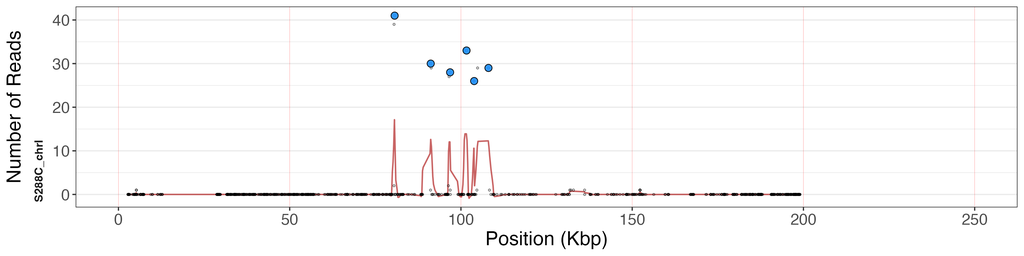

Because `--output` was a directory, the CLI auto-named the file `<sample>_chimera_<date>.png` inside it. Pass a full path instead (`--output results/chrI_run1.png`) to control the name directly.

03

## Get the peak table instead of the plot

Add `--peak-list` to get the same peak-detection pass as a CSV — positions, boundaries, height, and each peak's haplotype classification — instead of a PNG:

terminal

```
$ Rscript chimera_cli.R --sample-name Tutorial_chrI --peak-list \
    --output results/ \
    test_data/chrI.csv.gz test_data/chrI_SNPs.vcf.gz test_data/ref_genome.fasta.fai

... same load / filter / detect steps ...

Peak list written to: results/Tutorial_chrI_chimera_2026-07-07_peaks.csv
```

| peak_pos | height | start–end | snp_n | reads | haplotype_label |
| --- | --- | --- | --- | --- | --- |
| 80,578 | 17.13 | 79,578–81,778 | 41 | 48 | binary |
| 91,178 | 12.62 | 88,378–93,578 | 30 | 41 | binary |
| 96,578 | 12.05 | 95,978–100,178 | 28 | 45 | binary |
| 101,578 | 13.89 | 100,178–102,378 | 33 | 56 | binary |
| 103,778 | 10.60 | 102,378–103,978 | 26 | 53 | binary |
| 107,978 | 12.29 | 103,978–109,778 | 29 | 29 | internal_crossover |

Five of the six peaks are clean `binary` switches (REF run → ALT run, or vice versa). The peak at 107,978 is labeled `internal_crossover` — its underlying reads show a switch-back pattern rather than a single sustained transition, which is exactly the kind of case the chain analysis in the next step tries to resolve into an actual event call.

04

## Call recombination events with the chain analysis

`--chain-all` runs the full LOH + peak-fusion + event-calling pipeline and writes one CSV per pass, so you can inspect every intermediate stage rather than trusting a black box:

terminal

```
$ Rscript chimera_cli.R --sample-name Tutorial_chrI --chain-all \
    --output results/chain/ \
    test_data/chrI.csv.gz test_data/chrI_SNPs.vcf.gz test_data/ref_genome.fasta.fai

... overview plot built and saved as usual, then: ...
Computing coverage map ...

── Chain analysis ──────────────────────────────────────────────
[chain] Step 0: Computing LOH map ...
  LOH segments     → ..._step0_loh_segments.csv (6 segments)
[chain] Step 0a: Computing coverage map ...
  Coverage segments → ..._step0a_coverage_segments.csv (2 segments; baseline depth = 80.0)
[chain] Step 0b: Labeling peak haplotypes + computing peak pairs ...
  Labeled 6 / 6 peaks
  Peak pairs: 3 candidate pairs evaluated
[chain] Step 1: Building raw chains ...
  Raw tokens       → ..._step1_raw_tokens.csv (13 tokens across 1 chromosomes)
[chain] Step 2: Canonicalising (merging same-state gaps) ...
  Canonical tokens → ..._step2_canonical_tokens.csv (13 tokens; 0 merged from step 1)
[chain] Step 3: Scanning for recombination motifs ...
  Pre-reconcile events → ..._step3_events.csv (3 events)
[chain] Step 4: Reconciling other events (unresolved LOH/peaks) ...
  Final events     → ..._step4_final_events.csv (4 total; 3 high, 1 review)

── Chain analysis complete ─────────────────────────────────────
```

The number climbs from 6 raw peaks to 13 tokens (step 1) because the chain builder also encodes the flat, non-chimeric stretches between peaks as their own tokens — then step 2 merges any that share state across a small gap. What you actually want is the last file:

| event_class | start–end | length | support | confidence |
| --- | --- | --- | --- | --- |
| CO_TERM | 4,729–80,468 | 75.7 kb | 41 | high |
| CO_GC | 91,304–96,536 | 5.2 kb | 17 | high |
| CO_GC | 101,628–103,652 | 2.0 kb | 42 | high |
| CO_GC_subres | 108,033–108,033 | — | 30 | review |

The `internal_crossover` peak from step 03 resolved into a `CO_GC_subres` call — a gene-conversion event below the tract-resolution floor, flagged `review` because it has peak support but no independently resolvable LOH tract. That distinction (a real call with a confidence flag, vs. a peak sitting unclaimed) is the whole point of running the chain analysis instead of stopping at the peak list.

**Requires `loh_chain_analysis.R`** next to `chimera_functions.R`. The CLI checks for it at startup and errors immediately if `--chain-all` is passed without it, rather than failing partway through.

05

## Tune the analysis

Every parameter exposed in the Shiny sidebar has a matching flag. The defaults are reasonable for typical long-read coverage — reach for these when a run looks too noisy or too conservative:

[output not shown]

Change one parameter at a time and re-run with `--peak-list` first — it's the fastest way to see how a threshold shift changes what gets called a peak, before committing to a full `--chain-all` pass.

06

## Where things land

Every mode respects `--output` the same way: a bare path is treated as the exact file to write, a directory (or a path ending in `/`) gets an auto-generated `<sample>_chimera_<date>` filename inside it, and any missing parent directories are created for you. `--coverage-map` and `--chain-all` write their extra CSVs into that same resolved directory, alongside the primary output.

`<sample>_chimera_<date>.png`Default mode — genome-wide overview plot

`<sample>_chimera_<date>_peaks.csv`--peak-list — every detected peak with haplotype label

`<sample>_chimera_<date>_overview.rds`--overview-rds — re-plot later with readRDS() + print()

`<sample>_<date>_coverage_table.csv / _coverage_segments.csv`--coverage-map — per-position depth and collapsed segments

`<sample>_<date>_chain_step0…step4_*.csv`--chain-all — one CSV per pass, ending in step4_final_events.csv